# Practica_4

___Practica No. 4___  
___Autor:___ Alejandro Hernández  
___Fecha:___ 2023-05-02  
============================================  
___Revisión histórica:___

- Versión 1.0 | 2023-05-02 | Practica No. 4, Riesgo de crédito

============================================

### 1. Carga de librerías

```python
import pandas as pd
import numpy as np
seed = 10
np.random.seed(seed)

import datetime as dt
from datetime import datetime as dt

#from dataprep.eda.missing import plot_missing
#from dataprep.eda import plot, plot_correlation

# Visualización
import seaborn as sns
import matplotlib as mpl
import matplotlib.pyplot as plt
import plotly.express as px
from pylab import rcParams

#
from sklearn.manifold import TSNE # Análisis de separabilidad de las variables
from sklearn.decomposition import PCA, TruncatedSVD
import matplotlib.patches as mpatches
import time
import warnings
warnings.filterwarnings("ignore")

#
import sklearn
from sklearn.metrics import confusion_matrix
from sklearn.model_selection import train_test_split
from sklearn.preprocessing import StandardScaler
from collections import Counter

# Preprocesado de datos: Pipeline y ColumnTransformer
from sklearn.pipeline import Pipeline
from sklearn.compose import ColumnTransformer
from sklearn.impute import SimpleImputer
from sklearn.preprocessing import StandardScaler
from sklearn.compose import make_column_selector

#XGBoost
import xgboost as xgb
import pandas as pd
from sklearn.model_selection import train_test_split, GridSearchCV

#Curva  ROC
import scikitplot as skplt
import matplotlib.pyplot as plt
```

### 2. Carga de datos

```python
df = pd.read_csv("data/credit_risk_dataset.csv")
```

```python
df.head()
```

|  | person_age | person_income | person_home_ownership | person_emp_length | loan_intent | loan_grade | loan_amnt | loan_int_rate | loan_status | loan_percent_income | cb_person_default_on_file | cb_person_cred_hist_length |
| --- | --- | --- | --- | --- | --- | --- | --- | --- | --- | --- | --- | --- |
| 0 | 22 | 59000 | RENT | 123.0 | PERSONAL | D | 35000 | 16.02 | 1 | 0.59 | Y | 3 |
| 1 | 21 | 9600 | OWN | 5.0 | EDUCATION | B | 1000 | 11.14 | 0 | 0.10 | N | 2 |
| 2 | 25 | 9600 | MORTGAGE | 1.0 | MEDICAL | C | 5500 | 12.87 | 1 | 0.57 | N | 3 |
| 3 | 23 | 65500 | RENT | 4.0 | MEDICAL | C | 35000 | 15.23 | 1 | 0.53 | N | 2 |
| 4 | 24 | 54400 | RENT | 8.0 | MEDICAL | C | 35000 | 14.27 | 1 | 0.55 | Y | 4 |

```python
# Index 0. loan_amnt/person_income = loan_percent_income. Se pueden quitar las primeras 2.
35000/59000
```

```
0.5932203389830508
```

Variable objetivo salida: loan_status

```python
df.describe().transpose()
```

|  | count | mean | std | min | 25% | 50% | 75% | max |
| --- | --- | --- | --- | --- | --- | --- | --- | --- |
| person_age | 32581.0 | 27.734600 | 6.348078 | 20.00 | 23.00 | 26.00 | 30.00 | 144.00 |
| person_income | 32581.0 | 66074.848470 | 61983.119168 | 4000.00 | 38500.00 | 55000.00 | 79200.00 | 6000000.00 |
| person_emp_length | 31686.0 | 4.789686 | 4.142630 | 0.00 | 2.00 | 4.00 | 7.00 | 123.00 |
| loan_amnt | 32581.0 | 9589.371106 | 6322.086646 | 500.00 | 5000.00 | 8000.00 | 12200.00 | 35000.00 |
| loan_int_rate | 29465.0 | 11.011695 | 3.240459 | 5.42 | 7.90 | 10.99 | 13.47 | 23.22 |
| loan_status | 32581.0 | 0.218164 | 0.413006 | 0.00 | 0.00 | 0.00 | 0.00 | 1.00 |
| loan_percent_income | 32581.0 | 0.170203 | 0.106782 | 0.00 | 0.09 | 0.15 | 0.23 | 0.83 |
| cb_person_cred_hist_length | 32581.0 | 5.804211 | 4.055001 | 2.00 | 3.00 | 4.00 | 8.00 | 30.00 |

#### Remover duplicados

```python
print(f'Total registros de créditos: {len(df)}.  Valores unicos: {df.drop_duplicates().shape[0]}')
```

```
Total registros de créditos: 32581.  Valores unicos: 32416
```

```python
print(f"Porcentaje de datos no duplicados: {df.drop_duplicates().shape[0]/len(df)*100}")
```

```
Porcentaje de datos no duplicados: 99.4935698720113
```

```python
# Eliminar los duplicados
df = df.drop_duplicates()
```

### 3 Exploración de datos

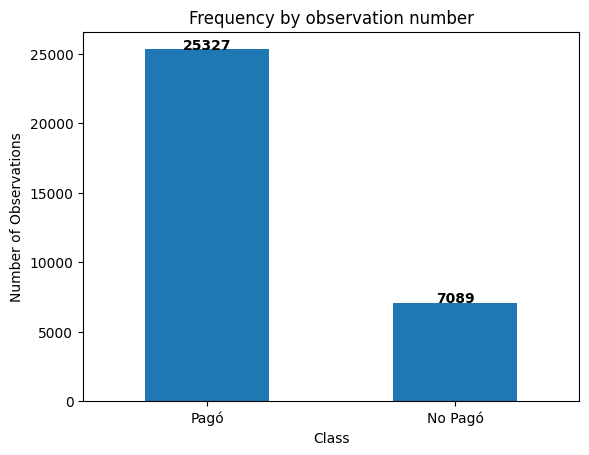

```python
# TODO Entender el balance de las clases visual o númerica. 1 pagó, 0 no pagó
count_classes = pd.value_counts(df['loan_status'], sort = True)
count_classes.plot(kind = 'bar', rot=0)
LABELS= ['Pagó','No Pagó']
plt.xticks(range(2), LABELS)
plt.title("Frequency by observation number")
plt.xlabel("Class")
plt.ylabel("Number of Observations");
for i, v in enumerate(count_classes):
    plt.text(i, v+1, str(v), ha='center', fontweight='bold')
```

```python
# Porcentaje de los que pagan
25327/(25327+7089)*100
```

```
78.13116979269496
```

```python
# Porcentaje de los no que pagan
7089/(25327+7089)*100
```

```
21.868830207305034
```

#### Análisis de correlación

```python
# Eliminar var person_income y loan_percent_income por dependencia con loan_amount.
# loan_amnt -> Se deja suponiendo que no crece drasticamente en el tiempo y al quitar la otra ya no hay correlación
# Variables de dinero no se recomiendan en los modelos por la inflación
# Para poder calcular la correlacionada se necesitaban las otras 2
df = df.drop(["person_income"], axis=1)
```

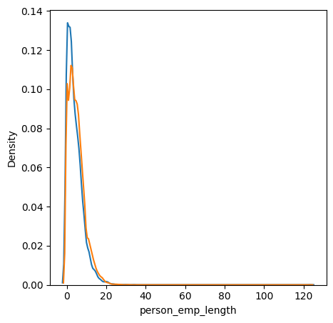

```python
buenos = df[df['loan_status'] == 1]
malos  = df[df['loan_status'] == 0]
# Distribución plot person_empt_length
variable_to_plot = 'person_emp_length'
plt.figure(figsize=(5,5))
ax = sns.distplot(buenos[variable_to_plot], label='buenos', hist=False)
ax = sns.distplot(malos[variable_to_plot], label='malos', hist=False)
ax.set(xlabel = variable_to_plot)
plt.show()
```

```python
df_corr=df.corr() #guardar la correlacion
df_corr
```

|  | person_age | person_emp_length | loan_amnt | loan_int_rate | loan_status | loan_percent_income | cb_person_cred_hist_length |
| --- | --- | --- | --- | --- | --- | --- | --- |
| person_age | 1.000000 | 0.163001 | 0.050680 | 0.011760 | -0.022698 | -0.042300 | 0.859215 |
| person_emp_length | 0.163001 | 1.000000 | 0.113183 | -0.056607 | -0.082817 | -0.053999 | 0.144889 |
| loan_amnt | 0.050680 | 0.113183 | 1.000000 | 0.146937 | 0.105736 | 0.572824 | 0.041865 |
| loan_int_rate | 0.011760 | -0.056607 | 0.146937 | 1.000000 | 0.335853 | 0.120207 | 0.015896 |
| loan_status | -0.022698 | -0.082817 | 0.105736 | 0.335853 | 1.000000 | 0.379697 | -0.016498 |
| loan_percent_income | -0.042300 | -0.053999 | 0.572824 | 0.120207 | 0.379697 | 1.000000 | -0.031457 |
| cb_person_cred_hist_length | 0.859215 | 0.144889 | 0.041865 | 0.015896 | -0.016498 | -0.031457 | 1.000000 |

### Análisis de la Varianza

```python
df_var = pd.DataFrame(
    {
        'Variable':np.array(df.var().index),
        'Variance': df.var().values
     }
)
df_var[df_var['Variance']<=0.1]
```

|  | Variable | Variance |
| --- | --- | --- |
| 5 | loan_percent_income | 0.011409 |

```python
df_var
```

|  | Variable | Variance |
| --- | --- | --- |
| 0 | person_age | 4.037459e+01 |
| 1 | person_emp_length | 1.718508e+01 |
| 2 | loan_amnt | 3.997692e+07 |
| 3 | loan_int_rate | 1.050849e+01 |
| 4 | loan_status | 1.708690e-01 |
| 5 | loan_percent_income | 1.140880e-02 |
| 6 | cb_person_cred_hist_length | 1.647573e+01 |

```python
# entre 50 y 75% porciento mayoría de los datos. Se decide dejarla y se verá después
df['loan_percent_income'].describe()
```

```
count    32416.000000
mean         0.170250
std          0.106812
min          0.000000
25%          0.090000
50%          0.150000
75%          0.230000
max          0.830000
Name: loan_percent_income, dtype: float64
```

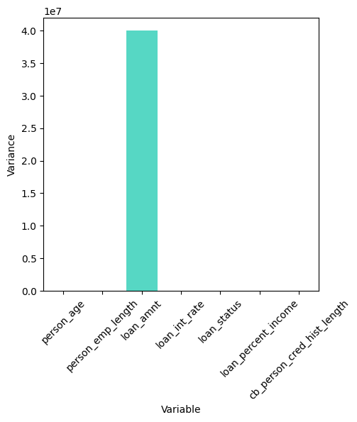

```python
# Diagrama de barrras visualizar comportamiento variable en
variable_to_plot = 'person_emp_length'
plt.figure(figsize=(5,5))
sns.barplot(df_var, x='Variable', y='Variance', palette='rainbow')
plt.xticks(rotation=45)
plt.show()
```

```python
def convert_cat_to_dummy(data, var_name, drop_values_list):
    # Getting  dummies
    variable_dummy = pd.get_dummies(data[var_name],prefix=var_name).astype('int')

    # Eliminar variables con multicolinealidad o irrelevantes
    variable_dummy = variable_dummy.drop(drop_values_list, axis=1)

    # Concatenar con df
    df_new = pd.concat([data, variable_dummy], axis=1)

    # Borrar variable original
    df_new = df_new.drop([var_name], axis=1)
    return df_new
```

# categóricas a dummy

```python
# Convertir variables categóricas a dummy
categorical_var = 'person_home_ownership'
df.groupby(categorical_var)[categorical_var].count()
```

```
person_home_ownership
MORTGAGE    13369
OTHER         106
OWN          2563
RENT        16378
Name: person_home_ownership, dtype: int64
```

```python
categorical_var = 'person_home_ownership'
multi_variables = ['person_home_ownership_OTHER']
df = convert_cat_to_dummy(df, categorical_var, multi_variables)
df.head()
```

|  | person_age | person_emp_length | loan_intent | loan_grade | loan_amnt | loan_int_rate | loan_status | loan_percent_income | cb_person_default_on_file | cb_person_cred_hist_length | person_home_ownership_MORTGAGE | person_home_ownership_OWN | person_home_ownership_RENT |
| --- | --- | --- | --- | --- | --- | --- | --- | --- | --- | --- | --- | --- | --- |
| 0 | 22 | 123.0 | PERSONAL | D | 35000 | 16.02 | 1 | 0.59 | Y | 3 | 0 | 0 | 1 |
| 1 | 21 | 5.0 | EDUCATION | B | 1000 | 11.14 | 0 | 0.10 | N | 2 | 0 | 1 | 0 |
| 2 | 25 | 1.0 | MEDICAL | C | 5500 | 12.87 | 1 | 0.57 | N | 3 | 1 | 0 | 0 |
| 3 | 23 | 4.0 | MEDICAL | C | 35000 | 15.23 | 1 | 0.53 | N | 2 | 0 | 0 | 1 |
| 4 | 24 | 8.0 | MEDICAL | C | 35000 | 14.27 | 1 | 0.55 | Y | 4 | 0 | 0 | 1 |

```python
# Convertir variables categóricas a dummy
categorical_var = 'loan_intent'
df.groupby(categorical_var)[categorical_var].count()
# Se elimina una porque con todas 0 se calculan other
```

```
loan_intent
DEBTCONSOLIDATION    5189
EDUCATION            6411
HOMEIMPROVEMENT      3594
MEDICAL              6042
PERSONAL             5498
VENTURE              5682
Name: loan_intent, dtype: int64
```

```python
categorical_var = 'loan_intent'
multi_variables = ['loan_intent_HOMEIMPROVEMENT']
df = convert_cat_to_dummy(df, categorical_var, multi_variables)
df.head()
```

|  | person_age | person_emp_length | loan_grade | loan_amnt | loan_int_rate | loan_status | loan_percent_income | cb_person_default_on_file | cb_person_cred_hist_length | person_home_ownership_MORTGAGE | person_home_ownership_OWN | person_home_ownership_RENT | loan_intent_DEBTCONSOLIDATION | loan_intent_EDUCATION | loan_intent_MEDICAL | loan_intent_PERSONAL | loan_intent_VENTURE |
| --- | --- | --- | --- | --- | --- | --- | --- | --- | --- | --- | --- | --- | --- | --- | --- | --- | --- |
| 0 | 22 | 123.0 | D | 35000 | 16.02 | 1 | 0.59 | Y | 3 | 0 | 0 | 1 | 0 | 0 | 0 | 1 | 0 |
| 1 | 21 | 5.0 | B | 1000 | 11.14 | 0 | 0.10 | N | 2 | 0 | 1 | 0 | 0 | 1 | 0 | 0 | 0 |
| 2 | 25 | 1.0 | C | 5500 | 12.87 | 1 | 0.57 | N | 3 | 1 | 0 | 0 | 0 | 0 | 1 | 0 | 0 |
| 3 | 23 | 4.0 | C | 35000 | 15.23 | 1 | 0.53 | N | 2 | 0 | 0 | 1 | 0 | 0 | 1 | 0 | 0 |
| 4 | 24 | 8.0 | C | 35000 | 14.27 | 1 | 0.55 | Y | 4 | 0 | 0 | 1 | 0 | 0 | 1 | 0 | 0 |

```python
# Convertir variables categóricas a dummy
categorical_var = 'loan_grade'
df.groupby(categorical_var)[categorical_var].count()
# Se elimina una porque con todas 0 se calculan other
```

```
loan_grade
A    10703
B    10387
C     6438
D     3620
E      963
F      241
G       64
Name: loan_grade, dtype: int64
```

```python
categorical_var = 'loan_grade'
multi_variables = ['loan_grade_E', 'loan_grade_F', 'loan_grade_G']
df = convert_cat_to_dummy(df, categorical_var, multi_variables)
df.head()
```

|  | person_age | person_emp_length | loan_amnt | loan_int_rate | loan_status | loan_percent_income | cb_person_default_on_file | cb_person_cred_hist_length | person_home_ownership_MORTGAGE | person_home_ownership_OWN | person_home_ownership_RENT | loan_intent_DEBTCONSOLIDATION | loan_intent_EDUCATION | loan_intent_MEDICAL | loan_intent_PERSONAL | loan_intent_VENTURE | loan_grade_A | loan_grade_B | loan_grade_C | loan_grade_D |
| --- | --- | --- | --- | --- | --- | --- | --- | --- | --- | --- | --- | --- | --- | --- | --- | --- | --- | --- | --- | --- |
| 0 | 22 | 123.0 | 35000 | 16.02 | 1 | 0.59 | Y | 3 | 0 | 0 | 1 | 0 | 0 | 0 | 1 | 0 | 0 | 0 | 0 | 1 |
| 1 | 21 | 5.0 | 1000 | 11.14 | 0 | 0.10 | N | 2 | 0 | 1 | 0 | 0 | 1 | 0 | 0 | 0 | 0 | 1 | 0 | 0 |
| 2 | 25 | 1.0 | 5500 | 12.87 | 1 | 0.57 | N | 3 | 1 | 0 | 0 | 0 | 0 | 1 | 0 | 0 | 0 | 0 | 1 | 0 |
| 3 | 23 | 4.0 | 35000 | 15.23 | 1 | 0.53 | N | 2 | 0 | 0 | 1 | 0 | 0 | 1 | 0 | 0 | 0 | 0 | 1 | 0 |
| 4 | 24 | 8.0 | 35000 | 14.27 | 1 | 0.55 | Y | 4 | 0 | 0 | 1 | 0 | 0 | 1 | 0 | 0 | 0 | 0 | 1 | 0 |

```python
# Convertir variables categóricas a dummy
categorical_var = 'cb_person_default_on_file'
df.groupby(categorical_var)[categorical_var].count()
# Se elimina una porque con todas 0 se calculan other
```

```
cb_person_default_on_file
N    26686
Y     5730
Name: cb_person_default_on_file, dtype: int64
```

```python
categorical_var = 'cb_person_default_on_file'
multi_variables = ['cb_person_default_on_file_Y']
df = convert_cat_to_dummy(df, categorical_var, multi_variables)
df.head()
```

|  | person_age | person_emp_length | loan_amnt | loan_int_rate | loan_status | loan_percent_income | cb_person_cred_hist_length | person_home_ownership_MORTGAGE | person_home_ownership_OWN | person_home_ownership_RENT | loan_intent_DEBTCONSOLIDATION | loan_intent_EDUCATION | loan_intent_MEDICAL | loan_intent_PERSONAL | loan_intent_VENTURE | loan_grade_A | loan_grade_B | loan_grade_C | loan_grade_D | cb_person_default_on_file_N |
| --- | --- | --- | --- | --- | --- | --- | --- | --- | --- | --- | --- | --- | --- | --- | --- | --- | --- | --- | --- | --- |
| 0 | 22 | 123.0 | 35000 | 16.02 | 1 | 0.59 | 3 | 0 | 0 | 1 | 0 | 0 | 0 | 1 | 0 | 0 | 0 | 0 | 1 | 0 |
| 1 | 21 | 5.0 | 1000 | 11.14 | 0 | 0.10 | 2 | 0 | 1 | 0 | 0 | 1 | 0 | 0 | 0 | 0 | 1 | 0 | 0 | 1 |
| 2 | 25 | 1.0 | 5500 | 12.87 | 1 | 0.57 | 3 | 1 | 0 | 0 | 0 | 0 | 1 | 0 | 0 | 0 | 0 | 1 | 0 | 1 |
| 3 | 23 | 4.0 | 35000 | 15.23 | 1 | 0.53 | 2 | 0 | 0 | 1 | 0 | 0 | 1 | 0 | 0 | 0 | 0 | 1 | 0 | 1 |
| 4 | 24 | 8.0 | 35000 | 14.27 | 1 | 0.55 | 4 | 0 | 0 | 1 | 0 | 0 | 1 | 0 | 0 | 0 | 0 | 1 | 0 | 0 |

```python
df_var=pd.DataFrame({'Variable':np.array(df.var().index),'Variance':df.var().values})
df_var[df_var['Variance']<=0.1]
```

|  | Variable | Variance |
| --- | --- | --- |
| 5 | loan_percent_income | 0.011409 |
| 8 | person_home_ownership_OWN | 0.072817 |
| 18 | loan_grade_D | 0.099205 |

# PCA y T-SNE

```python
df.head()
```

|  | person_age | person_emp_length | loan_amnt | loan_int_rate | loan_status | loan_percent_income | cb_person_cred_hist_length | person_home_ownership_MORTGAGE | person_home_ownership_OWN | person_home_ownership_RENT | loan_intent_DEBTCONSOLIDATION | loan_intent_EDUCATION | loan_intent_MEDICAL | loan_intent_PERSONAL | loan_intent_VENTURE | loan_grade_A | loan_grade_B | loan_grade_C | loan_grade_D | cb_person_default_on_file_N |
| --- | --- | --- | --- | --- | --- | --- | --- | --- | --- | --- | --- | --- | --- | --- | --- | --- | --- | --- | --- | --- |
| 0 | 22 | 123.0 | 35000 | 16.02 | 1 | 0.59 | 3 | 0 | 0 | 1 | 0 | 0 | 0 | 1 | 0 | 0 | 0 | 0 | 1 | 0 |
| 1 | 21 | 5.0 | 1000 | 11.14 | 0 | 0.10 | 2 | 0 | 1 | 0 | 0 | 1 | 0 | 0 | 0 | 0 | 1 | 0 | 0 | 1 |
| 2 | 25 | 1.0 | 5500 | 12.87 | 1 | 0.57 | 3 | 1 | 0 | 0 | 0 | 0 | 1 | 0 | 0 | 0 | 0 | 1 | 0 | 1 |
| 3 | 23 | 4.0 | 35000 | 15.23 | 1 | 0.53 | 2 | 0 | 0 | 1 | 0 | 0 | 1 | 0 | 0 | 0 | 0 | 1 | 0 | 1 |
| 4 | 24 | 8.0 | 35000 | 14.27 | 1 | 0.55 | 4 | 0 | 0 | 1 | 0 | 0 | 1 | 0 | 0 | 0 | 0 | 1 | 0 | 0 |

```python
df.isna().sum() > 0
```

```
person_age                        False
person_emp_length                  True
loan_amnt                         False
loan_int_rate                      True
loan_status                       False
loan_percent_income               False
cb_person_cred_hist_length        False
person_home_ownership_MORTGAGE    False
person_home_ownership_OWN         False
person_home_ownership_RENT        False
loan_intent_DEBTCONSOLIDATION     False
loan_intent_EDUCATION             False
loan_intent_MEDICAL               False
loan_intent_PERSONAL              False
loan_intent_VENTURE               False
loan_grade_A                      False
loan_grade_B                      False
loan_grade_C                      False
loan_grade_D                      False
cb_person_default_on_file_N       False
dtype: bool
```

```python
# Se llena con la media porque es conveniente
df['loan_int_rate']=df['loan_int_rate'].fillna(df['loan_int_rate'].mean())
# Se llena con 0s porque no afecta
df['person_emp_length']=df['person_emp_length'].fillna(0)


X=df.drop('loan_status',axis=1) # Loan status no se convierte a dummy porque es la variable objetivo
y=df['loan_status']
```

```python
# T-SNE Implementation
t0 = time.time()
X_reduced_tsne = TSNE(n_components=2, random_state=42).fit_transform(X.values)
t1 = time.time()
print("T-SNE took {:.2} s".format(t1 - t0))

# PCA Implementation
t0 = time.time()
X_reduced_pca = PCA(n_components=2, random_state=42).fit_transform(X.values)
t1 = time.time()
print("PCA took {:.2} s".format(t1 - t0))

# TruncatedSVD Implementation
t0 = time.time()
X_reduced_svd = TruncatedSVD(n_components=2, algorithm='randomized', random_state=42).fit_transform(X.values)
t1 = time.time()
print("Truncated SVD took {:.2} s".format(t1 - t0))
```

```
T-SNE took 2.7e+02 s
PCA took 0.18 s
Truncated SVD took 0.13 s
```

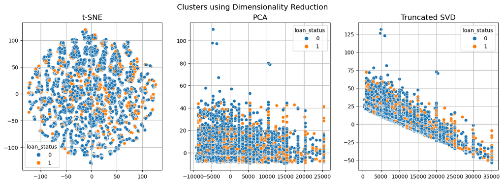

```python
f, ax = plt.subplots(1,3,figsize = (16,5))

# labels = ['No Fraud', 'Fraud']
f.suptitle('Clusters using Dimensionality Reduction', fontsize=14)

# t-SNE scatter plot
sns.scatterplot(x=X_reduced_tsne[:, 0], y=X_reduced_tsne[:, 1], hue = y,  ax=ax[0])
ax[0].set_title('t-SNE', fontsize=14)
ax[0].grid(True)

# PCA scatter plot
sns.scatterplot(x=X_reduced_pca[:, 0], y=X_reduced_pca[:, 1], hue = y,  ax=ax[1])
ax[1].set_title('PCA', fontsize=14)
ax[1].grid(True)

# TruncatedSVD scatter plot
sns.scatterplot(x=X_reduced_svd[:, 0], y=X_reduced_svd[:, 1], hue = y,  ax=ax[2])
ax[2].set_title('Truncated SVD', fontsize=14)
ax[2].grid(True)

plt.show()
```

# Modelo

```python
# Split test train
X_train, X_test, y_train, y_test = train_test_split(X, y, test_size = 0.3, random_state = 1)
```

```python
# Grid de hiperparámetros
grid = {
    'max_depth': (3, 6, 9),
    'eta': (0.1, 0.3, 0.5),
    'gamma': (0, 0.1, 0.2),
    'min_child_weight': (1, 2, 4),
}
```

```python
scale_pos_weight = 3.6
# Clasificador xgboost
xgb_model = xgb.XGBClassifier(scale_pos_weight=scale_pos_weight, objective='binary:logistic')
```

```python
# Optimización de hiperparametros por grid search
grid_search = GridSearchCV(xgb_model, param_grid=grid, scoring='roc_auc', cv=5)
grid_search.fit(X_train, y_train)
```

```
GridSearchCV(cv=5,
             estimator=XGBClassifier(base_score=None, booster=None,
                                     callbacks=None, colsample_bylevel=None,
                                     colsample_bynode=None,
                                     colsample_bytree=None,
                                     early_stopping_rounds=None,
                                     enable_categorical=False, eval_metric=None,
                                     feature_types=None, gamma=None,
                                     gpu_id=None, grow_policy=None,
                                     importance_type=None,
                                     interaction_constraints=None,
                                     learning_rate=None,...
                                     max_cat_threshold=None,
                                     max_cat_to_onehot=None,
                                     max_delta_step=None, max_depth=None,
                                     max_leaves=None, min_child_weight=None,
                                     missing=nan, monotone_constraints=None,
                                     n_estimators=100, n_jobs=None,
                                     num_parallel_tree=None, predictor=None,
                                     random_state=None, ...),
             param_grid={'eta': (0.1, 0.3, 0.5), 'gamma': (0, 0.1, 0.2),
                         'max_depth': (3, 6, 9),
                         'min_child_weight': (1, 2, 4)},
             scoring='roc_auc')
```

```python
print(f"Puntaje ROC AUC: {grid_search.best_score_}")
print(f"Mejores hiperparámetros: {grid_search.best_params_}")
```

```
Puntaje ROC AUC: 0.9223850857586282
Mejores hiperparámetros: {'eta': 0.1, 'gamma': 0.1, 'max_depth': 6, 'min_child_weight': 2}
```

```python
xgb_final_model = xgb.XGBClassifier(
    scale_pos_weight = scale_pos_weight, # Peso para escalar la clase minoritaria
    objective = 'binary:logistic', # Regresión logística binaria para optimizar  el modelo
    **grid_search.best_params_ # Desempaquetado de los parámetros Óptimos
    )
xgb_final_model.fit(X_train, y_train)
```

```
XGBClassifier(base_score=None, booster=None, callbacks=None,
              colsample_bylevel=None, colsample_bynode=None,
              colsample_bytree=None, early_stopping_rounds=None,
              enable_categorical=False, eta=0.1, eval_metric=None,
              feature_types=None, gamma=0.1, gpu_id=None, grow_policy=None,
              importance_type=None, interaction_constraints=None,
              learning_rate=None, max_bin=None, max_cat_threshold=None,
              max_cat_to_onehot=None, max_delta_step=None, max_depth=6,
              max_leaves=None, min_child_weight=2, missing=nan,
              monotone_constraints=None, n_estimators=100, n_jobs=None,
              num_parallel_tree=None, predictor=None, ...)
```

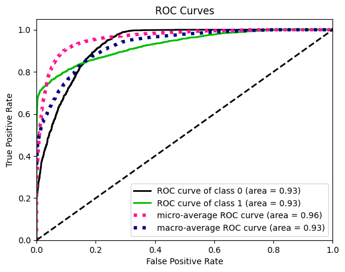

```python
# Curva roc
y_pred_proba = xgb_final_model.predict_proba(X_test)
skplt.metrics.plot_roc_curve(y_test, y_pred_proba)
plt.show()
```

```python
# Evaluación del modelo
y_pred = xgb_final_model.predict(X_test)
predictions=[round(value) for value  in y_pred]
array=confusion_matrix(y_test,predictions)
df=pd.DataFrame(array,index=['Pagaron','No Pagaron'],columns=['Pagaron','No Pagaron'])
df.head()
```

|  | Pagaron | No Pagaron |
| --- | --- | --- |
| Pagaron | 7146 | 434 |
| No Pagaron | 504 | 1641 |

```
<function matplotlib.pyplot.show(close=None, block=None)>
```

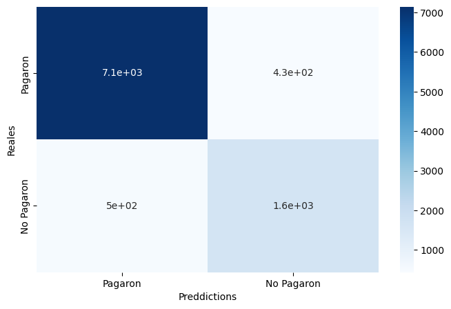

```python
plt.figure(figsize=(8,5))
sns.heatmap(df,annot=True,cmap='Blues')
plt.xlabel('Preddictions')
plt.ylabel('Reales')
plt.show
```

```python
# Métricas más usadas
from sklearn.metrics import accuracy_score, precision_score, recall_score, roc_auc_score, f1_score
print(f'Accuracy: {accuracy_score(y_test, y_pred)}')
print(f"Precision: {precision_score(y_test, y_pred, average='macro')}")
print(f"Recall: '{recall_score(y_test, y_pred, average='macro')}")
print(f"F1 score: {f1_score(y_test, y_pred, average='macro')}")
print(f"ROC AUC: {roc_auc_score(y_test, y_pred_proba[:,1], multi_class='ovr')}")
```

```
Accuracy: 0.903547557840617
Precision: 0.8624805102763997
Recall: '0.8538895141797517
F1 score: 0.8580680746717784
ROC AUC: 0.9277362830660983
```

```python
# Model Lift
# https://towardsdatascience.com/model-lift-the-missing-link-70eb37460e67
def lift (test, pred, cardinaility):
    res = pd.DataFrame(np.column_stack((test, pred)),
                       columns=['Target','PR_0', 'PR_1'])
    res['scr_grp'] = pd.qcut(res['PR_1'], cardinaility, labels=False)+1
    crt = pd.crosstab(res.scr_grp, res.Target).reset_index()
    crt = crt.rename(columns= {'Target':'Np',1.0: 'Negatives', 0.0: 'Positives'})
    B = crt['Negatives'].sum()
    G = crt['Positives'].sum()
    avg_resp_rate = G/(G+B)
    crt['resp_rate'] = round(crt['Positives']/(crt['Positives']+crt['Negatives']),2)
    crt['lift'] = round((crt['resp_rate']/avg_resp_rate),2)
    crt['rand_resp'] = 1/cardinaility
    crt['cmltv_p'] = round((crt['Positives']).cumsum(),2)
    crt['cmltv_p_perc'] = round(((crt['Positives']/G).cumsum())*100,1)
    crt['cmltv_n'] = round((crt['Negatives']).cumsum(),2)
    crt['cmltv_n_perc'] = round(((crt['Negatives']/B).cumsum())*100,1)
    crt['cmltv_rand_p_perc'] = (crt.rand_resp.cumsum())*100
    crt['cmltv_resp_rate'] = round(crt['cmltv_p']/(crt['cmltv_p']+crt['cmltv_n']),2)
    crt['cmltv_lift'] = round(crt['cmltv_resp_rate']/avg_resp_rate,2)
    crt['KS']=round(crt['cmltv_p_perc']-crt['cmltv_rand_p_perc'],2)
    crt = crt.drop(['rand_resp','cmltv_p','cmltv_n',], axis=1)
    print('average response rate: ' , avg_resp_rate)
    return crt
```

```python
Modelo_Ordenado = lift(y_test,y_pred_proba,10)
Modelo_Ordenado
```

```
average response rate:  0.7794344473007712
```

| Target | scr_grp | Positives | Negatives | resp_rate | lift | cmltv_p_perc | cmltv_n_perc | cmltv_rand_p_perc | cmltv_resp_rate | cmltv_lift | KS |
| --- | --- | --- | --- | --- | --- | --- | --- | --- | --- | --- | --- |
| 0 | 1 | 973 | 0 | 1.00 | 1.28 | 12.8 | 0.0 | 10.0 | 1.00 | 1.28 | 2.8 |
| 1 | 2 | 960 | 12 | 0.99 | 1.27 | 25.5 | 0.6 | 20.0 | 0.99 | 1.27 | 5.5 |
| 2 | 3 | 946 | 27 | 0.97 | 1.24 | 38.0 | 1.8 | 30.0 | 0.99 | 1.27 | 8.0 |
| 3 | 4 | 920 | 52 | 0.95 | 1.22 | 50.1 | 4.2 | 40.0 | 0.98 | 1.26 | 10.1 |
| 4 | 5 | 909 | 64 | 0.93 | 1.19 | 62.1 | 7.2 | 50.0 | 0.97 | 1.24 | 12.1 |
| 5 | 6 | 881 | 91 | 0.91 | 1.17 | 73.7 | 11.5 | 60.0 | 0.96 | 1.23 | 13.7 |
| 6 | 7 | 870 | 102 | 0.90 | 1.15 | 85.2 | 16.2 | 70.0 | 0.95 | 1.22 | 15.2 |
| 7 | 8 | 784 | 189 | 0.81 | 1.04 | 95.6 | 25.0 | 80.0 | 0.93 | 1.19 | 15.6 |
| 8 | 9 | 337 | 635 | 0.35 | 0.45 | 100.0 | 54.6 | 90.0 | 0.87 | 1.12 | 10.0 |
| 9 | 10 | 0 | 973 | 0.00 | 0.00 | 100.0 | 100.0 | 100.0 | 0.78 | 1.00 | 0.0 |

# Feature Importance

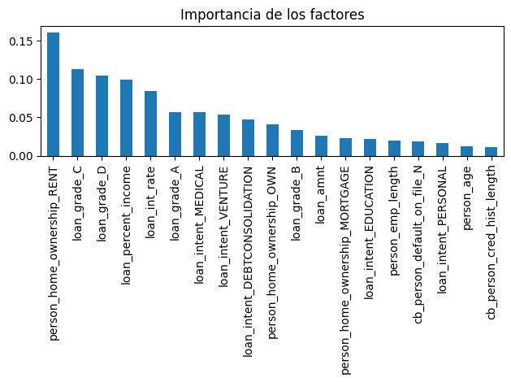

```python
feature_importance =pd.Series(xgb_final_model.feature_importances_,index=xgb_final_model.feature_names_in_)
feature_importance = feature_importance.where(feature_importance >0.001).dropna().sort_values(ascending=False)
fig, ax = plt.subplots()
feature_importance.plot.bar()
ax.set_title("Importancia de los factores")
fig.tight_layout()
```

# Conclusiones

El AUC que es el area bajo la curva roc nos da una buena idea de qué tan bien funciona el modelo.

Si AUC es 0, el modelo predice al reves, si AUC es .5 el modelo superpone las clases y no predice nada bien, el AUC utopico es 1, pero podría indicar sobre ajuste. En este caso el AUC es de .92 lo que indica que el modelo es de hecho muy bueno! Y el area bajo la curva es amplia.

Sin embargo, es de vital importancia entender que esto no siempre nos dice cómo se va a comportar el modelo en la vida real, por lo que hay que hacer analisis más profundos como la ordenación de modelo.

Andrzej Szymanski explica que la curva ROC es muy buena para modelos donde es importante saber qué tan preciso un modelo capturará casos que necesitamos si o si capturar como comportamiento fraudulento, clasificacion de enfermedades o comportamiento crediticio, pero esa no es siempre la necesidad del mercado.

EN ESTE CASO parece que el estudio no busca predecir si un cliente pagará o no, sino entender el comportamiento del cliente y cómo incentivar a que mejore sus habitos financieros, aqui es donde toma especial relevancia Model Liftr

Feature importance nos puede dar aún más pistas sobre cómo sugerirle al cliente que maneje su camapaña una vez acotado el publico al que se centrará, por ejemplo sugerirle pasivamente al cliente que busque rentas más baratas para que mejore su calidad de vida.